# Contact - Tracing Database Model

**Epidemologists can expect the following from the database model**

1.Research on people who and why are more prone to the disease.

2.Spreading Patterns.

3.Effect on the people with past health complications.

4.Effectiveness of precautions.

5.Effectiveness of particular drug

**We have considered the following Use Cases**

Use Case 1: The details of both patients and their contacts(who interacted with the patients) along with the locations they visited.

Use Case 2: The symptom details of the patients after contracting the disease/infection.

Use Case 3: The test results of both patients and contacts after testing.

Use Case 4: The treatment details of patients and also the drugs used to treat the patients

Use Case 5: The health and monitoring details of contacts by the health care workers.

**Assumptions:**

1. A citizen with a unique SSN can be admitted as a patient multiple times (A citizen with a SSN can have multiple patientID’s as they can be infected more than once)
2. When a contact is tested positive, the details of that contact are added as a new record in ‘patient’ table.
3. Health Care Worker is expected to provide any one of the following services : Contact Tracing, Treatment Monitoring, Patient Support.
4. A patient is assigned a minimum of one health care worker.
5. A patient can be tested positive multiple number of times and a patient may not be tested if they are deceased.
6. A patient may not infect contacts when patient visits any address or can infect one or more contacts.
7. A patient may infect other unknown contacts by visiting any address.

**TASK 1: CONCEPTUAL UML CLASS DIAGRAM**

[figure not shown]

**TASK 2: LOGICAL DATA MODEL**

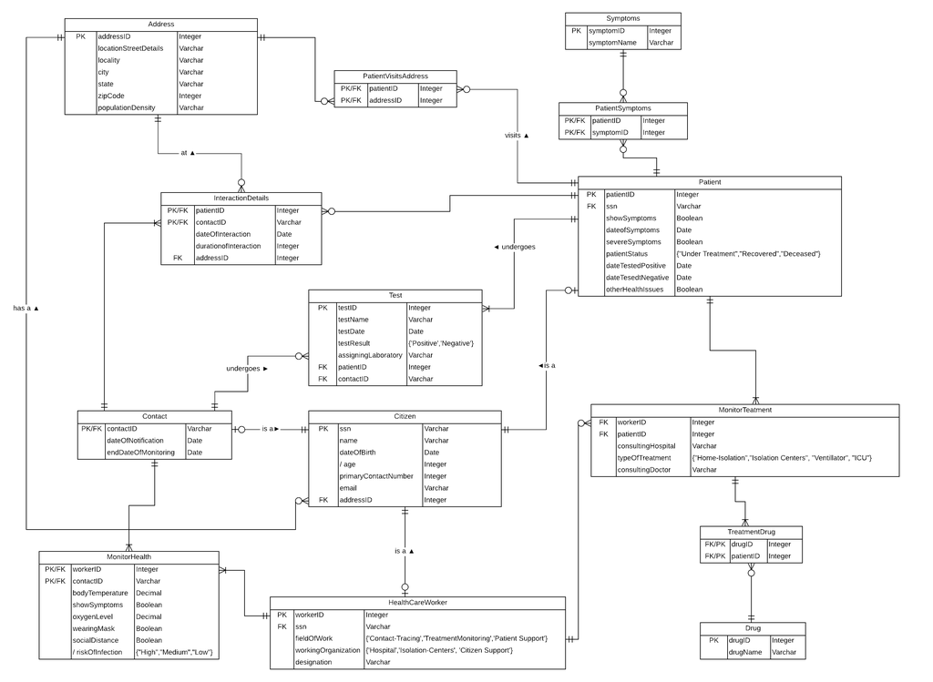

__________________________________________________________________________________________________________

**TASK 3: RELATIONAL SCHEMA**

**Un-normalized Relational Schema and their functional dependencies:**

ContactTracingSchema (ADDRESS, CITIZEN, HEALTHCAREWORKER, PATIENT, CONTACT, TEST, MONITORTREATMENT, TREATMENTDRUG, DRUG, MONITORHEALTH, INTERACTIONDETAILS, PATIENTVISITSADDRESS, SYMPTOMS, PATIENTSYMPTOMS)

ADDRESS (addressID, name, locationStreetDetails, city, state, zipCode, populationDensity)  
addressID –> name, locationStreetDetails, zipCode, populationDensity zipCode –> city, state

CITIZEN (ssn, name, dateOfBirth, age, primaryContactNumber, email, *addressID*)  
ssn –> name, dateOfBirth, age, primaryContactNumber, email, addressID

HEALTHCAREWORKER (workerID, *ssn*, fieldOfWork, workingOrganization, designation)  
workerID –> ssn, fieldOfWork, workingOrganization, designation ssn –> workerID, fieldOfWork, workingOrganization, designation

PATIENT (patientID, *ssn*, showSymptoms, dateOfSymptoms, severeSymptoms, patientStatus, dateTestedPositive, dateTestedNegative, otherHealthIssues)  
patientID –> ssn, showSymptoms, dateOfSymptoms, severeSymptoms, patientStatus, dateTestedPositive, dateTestedNegative, otherHealthIssues

CONTACT (*contactID*, dateOfNotification, endDateOfMonitoring)  
contactID –> dateOfNotification, endDateOfMonitoring

TEST (testID, testName, testDate, testResult, assigningLaboratory, *patientID*, *contactID*)  
testID –> testName, testDate, testResult, assigningLaboratory, patientID, contactID

MONITORTREATMENT (*workerID*, *patientID*, consultingHospital, consultingDoctor, typeOfTreatment)  
workerID, patientID –> consultingHospital, consultingDoctor, typeOfTreatment

DRUG (drugID, drugName)  
drugID –> drugName

TREATMENTDRUG (*drugID*, *patientID*)  
patientID ,drugID –> drugID

MONITORHEALTH (*workerID*, *contactID*, bodyTemperature, showSymptoms, oxygenLevel, wearingMask, socialDistance, riskOfInfection)  
workerID, contactID –> bodyTemperature, showSymptoms, oxygenLevel, wearingMask, socialDistance, riskOfInfection

INTERACTIONDETAILS (*patientID*, *contactID*, dateOfInteraction, durationOfInteraction, *addressID*)  
patientID, contactID –> dateOfInteraction, durationOfInteraction, addressID

PATIENTVISITSADDRESS (*patientID*, *addressID*)  
patientID, addressID –> addressID SYMPTOMS (symptomID, symptomName)  
symptomID –> symptomName

PATIENTSYMPTOMS (*patientID*, *symptomID*)  
patientID, symptomID –> symptomID

NOTE: ContactID is foreign refercing ssn from Citizen.

**Functional Dependencies for BCNF Normalization**

The below Functional Dependencies are after resolving transitive and partial dependencies to confirm BCNF:

ADDRESS addressID –> name, locationStreetDetails, zipCode, populationDensity

ADDRESSBYCITY addressID –> city, state

CITIZEN ssn –> name, dateOfBirth, age, primaryContactNumber, email, addressID

HEALTHCAREWORKER workerID –> fieldOfWork, workingOrganization, designation

CITIZENHEALTHCAREWORKER workerID, ssn –> ssn

PATIENT patientID –> ssn, showSymptoms, dateOfSymptoms, severeSymptoms, patientStatus, dateTestedPositive, dateTestedNegative, otherHealthIssues

CONTACT contactID –> dateOfNotification, endDateOfMonitoring

TEST testID –> testName, testDate, testResult, assigningLaboratory

CONTACTTEST contactID,testID –> contactID

PATIENTTEST patientID,testID –> patientID

MONITORTREATMENT workerID, patientID–> patientID

PATIENTTREATMENT patientID –> consultingHospital, typeOfTreatment, consultingDoctor

DRUG drugID –> drugName

TREATMENTDRUG drugID,patientID –> patientID

MONITORHEALTH workerID,contactID –> contactID

CONTACTHEALTH contactID –> bodyTemperature, showSymptoms, oxygenLevel, wearingMask, socialDistance, riskOfInfection)

INTERACTIONDETAILS patientID, contactID –> dateOfInteraction, durationOfInteraction, addressID

PATIENTVISITSADDRESS patientID,addressID –> addressID

SYMPTOMS symptomID –> symptomName

PATIENTSYMPTOMS patientID ,symptoms–> patientID

**Normalized Schema**

ContactTracingSchema (ADDRESS, ADDRESSBYCITY, CITIZEN, HEALTHCAREWORKER, CITIZENHEALTHCAREWORKER, PATIENT, CITIZENASPATIENT, CONTACT, TEST, CONTACTTEST, PATIENTTEST, MONITORTREATMENT, PATIENTTREATMENT, TREATMENTDRUG, DRUG, MONITORHEALTH, CONTACTHEALTH, INTERACTIONDETAILS, PATIENTVISITSADDRESS, SYMPTOMS, PATIENTSYMPTOMS)

ADDRESS (addressID, name, locationStreetDetails, populationDensity, zipCode)

ADDRESSBYCITY (*addressID*, city, state)

CITIZEN (ssn, name, dateOfBirth, age, primaryContactNumber, email, *addressID*)

HEALTHCAREWORKER (workerID, fieldOfWork, workingOrganization, designation)

CITIZENHEALTHCAREWORKER (*workerID*, *ssn*)

PATIENT (patientID, showSymptoms, dateOfSymptoms, severeSymptoms, patientStatus, dateTestedPositive, dateTestedNegative, otherHealthIssues, *ssn*)

CONTACT (*contactID*, dateOfNotification, endDateOfMonitoring)

TEST (testID, testName, testDate, testResult, assigningLaboratory)

CONTACTTEST (*contactID*, *testID*)

PATIENTTEST (*patientID*, *testID*)

MONITORTREATMENT (*workerID*, *patientID*)

PATIENTTREATMENT (*patientID*, consultingHospital, typeOfTreatment, consultingDoctor)

DRUG (drugID, drugName)

TREATMENTDRUG (*drugID*, *patientID*)

MONITORHEALTH (*workerID*, *contactID*)

CONTACTHEALTH (*contactID*, bodyTemperature, showSymptoms, oxygenLevel, wearingMask, socialDistance, riskOfInfection)

INTERACTIONDETAILS (*patientID*, *contactID*, dateOfInteraction, durationOfInteraction,*addressID*)

PATIENTVISITSADDRESS (*patientID*, *addressID*)

SYMPTOMS (symptomID, symptomName)

PATIENTSYMPTOMS (*patientID*, *symptomID*)

**TASK 4: Create Table Statements In MySQL**

BELOW ARE THE QUERIES WHICH ARE USED TO GENERATE TABLES IN MYSQL :

create schema contacttracing; use contacttracing;

create table address( addressID int PRIMARY KEY, streetLocationDetails varchar(50), populationDensity varchar(50) check(populationDensity IN (‘High’,‘Medium’,‘Low’)), zipCode integer NOT NULL );

create table addressbycity( addressID int PRIMARY KEY, city varchar(50) NOT NULL, state varchar(50) NOT NULL, FOREIGN KEY (addressID) references address(addressID) );

create table citizen( ssn varchar(12) PRIMARY KEY, name varchar(50) NOT NULL, dateOfBirth date NOT NULL, age int, primaryContactNumber varchar(12) NOT NULL check(length(primaryContactNumber) between 10 and 12), email varchar(100), addressID int NOT NULL, foreign key(addressID) references address(addressID) );

create table healthcareworker( workerID int PRIMARY KEY, fieldOfWork varchar(30) NOT NULL CHECK(fieldOfWork IN (‘Contact-Tracing’,‘TreatmentMonitoring’,‘Patient-Support’)), workingOrganization varchar(30) NOT NULL CHECK(workingOrganization IN (‘Hospital’,‘Isolation-Centers’,‘Citizen Support’)), designation varchar(30) NOT NULL );

create table citizenhealthcareworker( workerID int, ssn varchar(12), PRIMARY KEY(workerID,ssn), FOREIGN KEY(workerID) references healthcareworker(workerID), FOREIGN KEY(ssn) references citizen(ssn) );

create table patient( patientID int PRIMARY KEY, showSymptoms boolean NOT NULL, dateOfSymptoms date, severeSymptoms boolean, patientStatus varchar(30) CHECK(patientStatus IN (‘Under Treatment’,‘Recovered’,‘Deceased’)), dateTestedPositive date NOT NULL, dateTestedNegative date, otherHealthIssues boolean NOT NULL, ssn varchar(12) NOT NULL, FOREIGN KEY(ssn) references citizen(ssn) );

create table contact( contactID varchar(12) PRIMARY KEY, dateOfNotification date NOT NULL, endDateOfMonitoring date, FOREIGN KEY(contactID) references citizen(ssn) );

create table test( testID int PRIMARY KEY, testName varchar(30) NOT NULL, testDate date NOT NULL, testResult varchar(10) check(testResult in (‘Positive’,‘Negative’)), assigningLaboratory varchar(50) NOT NULL );

create table contacttest( contactID varchar(12), testID int, PRIMARY KEY(contactID,testID), FOREIGN KEY(contactID) references contact(contactID), FOREIGN KEY(testID) references test(testID) );

create table patienttest( patientID int, testID int, PRIMARY KEY(patientID,testID), FOREIGN KEY(patientID) references patient(patientID), FOREIGN KEY(testID) references test(testID) );

create table monitortreatment( workerID int, patientID int, PRIMARY KEY(workerID,patientID), FOREIGN KEY(workerID) references healthcareworker(workerID), FOREIGN KEY(patientID) references patient(patientID) );

create table patienttreatment( patientID int PRIMARY KEY, consultingHospital varchar(50) NOT NULL, typeOfTreatment varchar(30) NOT NULL CHECK(typeOfTreatment in (‘Home-Isolation’,‘Isolation Centers’,‘Ventillator’,‘ICU’)), consultingDoctor varchar(30) NOT NULL, FOREIGN KEY(patientID) references patient(patientID) );

CREATE TABLE DRUG( drugID int PRIMARY KEY auto_increment, drugName varchar(50) NOT NULL );

create table treatmentdrug( drugID int, patientID int, PRIMARY KEY(drugID,patientID), FOREIGN KEY(drugID) references drug(drugID), FOREIGN KEY(patientID) references patienttreatment(patientID) );

create table monitorhealth( workerID int, contactID varchar(12), PRIMARY KEY(workerID,contactID), FOREIGN KEY(workerID) references healthcareworker(workerID), FOREIGN KEY(contactID) references contact(contactID) );

create table contacthealth( contactID varchar(12) PRIMARY KEY, bodyTemperature decimal NOT NULL, showSymptoms boolean NOT NULL, oxygenLevel decimal NOT NULL, wearingMask boolean NOT NULL, socialDistance boolean NOT NULL, riskOfInfection varchar(10) CHECK(riskOfInfection in (‘High’,‘Medium’,‘Low’)), FOREIGN KEY(contactID) references contact(contactID) );

create table interactiondetails( patientID int, contactID varchar(12), dateOfInteraction date NOT NULL, durationOfInteraction date, addressID int, PRIMARY KEY(patientID,contactID), FOREIGN KEY(patientID) references patient(patientID), FOREIGN KEY(contactID) references contact(contactID), FOREIGN KEY(addressID) references address(addressID) );

create table patientvisitsaddress( patientID int, addressID int, PRIMARY KEY(patientID,addressID), FOREIGN KEY(patientID) references patient(patientID), FOREIGN KEY(addressID) references address(addressID) );

CREATE TABLE symptoms( symptomID int PRIMARY KEY, symptomName varchar(50) NOT NULL );

CREATE TABLE patientsymptoms( patientID int, symptomID int, PRIMARY KEY(patientID,symptomID), FOREIGN KEY(patientID) REFERENCES patient(patientID), FOREIGN KEY(symptomID) REFERENCES symptoms(symptomID) );

the SQL Queries Execution Log Screenshot Proves creation of tables for above queries with appropriate constraints

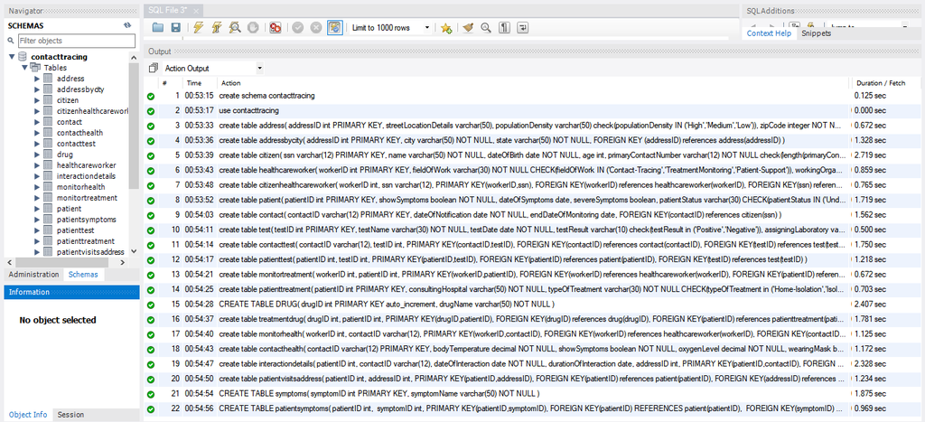

Execution Log

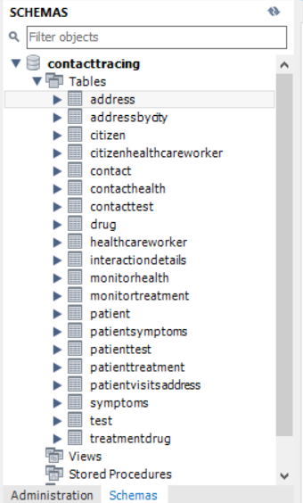

Schema Navigator in MySQL

**TASK 5 and TASK 6:**

Successful establishment of MySQL Connection and retreival of data from MySQL database which implies the completion of Task 5 and 6.

**Establishing Database Connectivity to MySQL localhost**

```r
library(RMySQL)
conn = dbConnect(MySQL(),user='root',password='Sravya0!',dbname='contacttracing',host= 'localhost')
conn
```

```
## <MySQLConnection:0,0>
```

THe below queries and their outputs prove this connectivity:

**Query1 :Details of treatment,and drug used by a patient**

```r
resultset1 = dbSendQuery(conn, 'SELECT DISTINCT patient.patientID,citizen.name,patientStatus,otherHealthIssues,typeOfTreatment,drug.drugName, citizen.age FROM
patient,citizen,patienttreatment,treatmentdrug,drug where
patient.ssn=citizen.ssn and patient.patientid=patienttreatment.patientID and patient.patientID=treatmentdrug.patientID and treatmentdrug.drugID=drug.drugID');
Query1 = fetch(resultset1, -1);
Query1
```

| patientID | name | patientStatus | otherHealthIssues | typeOfTreatment | drugName | age |
| --- | --- | --- | --- | --- | --- | --- |
| 1001 | Jerome | Deceased | 1 | Isolation Centers | Favipiravir | 61 |
| 1001 | Jerome | Deceased | 1 | Isolation Centers | Vitamin D | 61 |
| 1002 | Carly | Under Treatment | 0 | ICU | Remedesivir | 89 |
| 1002 | Carly | Under Treatment | 0 | ICU | Dexamethose | 89 |
| 1004 | Emma | Under Treatment | 0 | Home-Isolation | Vitamin C | 83 |
| 1004 | Emma | Under Treatment | 0 | Home-Isolation | Dexamethose | 83 |
| 1004 | Emma | Under Treatment | 0 | Home-Isolation | Tocilizumad | 83 |
| 1005 | Steven | Recovered | 0 | Isolation Centers | Hydroxychloroquine | 51 |
| 1005 | Steven | Recovered | 0 | Isolation Centers | Vitamin B12 | 51 |
| 1005 | Steven | Recovered | 0 | Isolation Centers | Itolizumab | 51 |

[output cut: 25 more lines]

```r
dbClearResult(resultset1)
```

```
## [1] TRUE
```

**Query2: Details of patients who have interacted with more than 2 contacts, along with their respective count**

```r
resultset2 = dbSendQuery(conn, "select patient.patientID,citizen.ssn,citizen.name,count(*) as NumberOfContacts,
citizen.primaryContactNumber,citizen.email from citizen,patient,interactiondetails where
citizen.ssn=patient.ssn and patient.patientID=interactiondetails.patientID
group by interactiondetails.patientID having count(*) > 2")
Query2 = fetch(resultset2, -1)
Query2
```

| patientID | ssn | name | NumberOfContacts | primaryContactNumber | email |
| --- | --- | --- | --- | --- | --- |
| 1001 | JWDB25YN6447 | Jerome | 3 | 15278920973 | at.libero@posuere.net |
| 1002 | PFWX42UL8738 | Carly | 3 | 14492889333 | risus@gravida.edu |
| 1003 | YXSH64FS4539 | Geraldine | 3 | 18986640013 | sit.amet.massa@metusurna.org |
| 1004 | JELV12QL0218 | Emma | 3 | 15935415866 | eros.nec.tellus@adipiscingelit.org |
| 1005 | QUAE59QK3577 | Steven | 3 | 15092513732 | risus@lacusvestibulumlorem.com |
| 1006 | JELV12QL0218 | Emma | 3 | 15935415866 | eros.nec.tellus@adipiscingelit.org |
| 1007 | JELV12QL0218 | Emma | 3 | 15935415866 | eros.nec.tellus@adipiscingelit.org |
| 1008 | KDYF20ZX2729 | Hanna | 3 | 17859300361 | adipiscing@facilisis.edu |
| 1012 | MYPS34DO0713 | Amelia | 4 | 18507470077 | sagittis.semper@ullamcorperDuis.org |
| 1013 | DHEM81ZT0363 | Aimee | 4 | 16239775899 | venenatis.a@accumsanconvallis.ca |

[output cut: 8 more lines]

```r
dbClearResult(resultset2)
```

```
## [1] TRUE
```

**Query3: Patients deceased without severe symptoms but having other health issues**

```r
resultset3 = dbSendQuery(conn,"select count(*) as PatientsDeceasedCount from patient where severeSymptoms=0 and otherHealthIssues=1 and patientStatus='Deceased'")
Query3 = fetch(resultset3, -1)
Query3
```

| PatientsDeceasedCount |
| --- |
| 7 |

```r
dbClearResult(resultset3)
```

```
## [1] TRUE
```

**Query4: Details of those individuals who became a patient more than once(who got infected more than once**

```r
resultset4 = dbSendQuery(conn, "select citizen.ssn,citizen.name,dateOfBirth,age,primaryContactNumber,email,address.locationStreetDetails,
city,state,zipCode,count(*) as NumberOfTimesInfected from patient,citizen,address,addressbycity where
patient.ssn=citizen.ssn and citizen.addressID=address.addressID and address.addressID=addressbycity.addressID
group by patient.ssn having count(*) > 1")
Query4 = fetch(resultset4, -1);
Query4
```

| ssn | name | dateOfBirth | age | primaryContactNumber | email | locationStreetDetails | city | state | zipCode | NumberOfTimesInfected |
| --- | --- | --- | --- | --- | --- | --- | --- | --- | --- | --- |
| DMCD51YA9274 | Erasmus | 1987-05-23 | 33 | 11036009698 | vel.arcu@blanditviverraDonec.net | Ap #253-526 Molestie Avenue | South Portland | Maine | 64907 | 3 |
| JELV12QL0218 | Emma | 1936-11-19 | 83 | 15935415866 | eros.nec.tellus@adipiscingelit.org | P.O. Box 408, 3824 Fermentum Rd. | Chandler | Arizona | 39206 | 3 |
| OHDP71XR0014 | Eagan | 1991-09-06 | 28 | 16068696493 | vel@dictumProineget.org | 2262 Pellentesque Rd. | Southaven | Mississippi | 92396 | 2 |
| PFWX42UL8738 | Carly | 1931-01-21 | 89 | 14492889333 | risus@gravida.edu | 1996 Magna Av. | Green Bay | Wisconsin | 41627 | 2 |
| YTVB50GK0396 | Rosalyn | 2011-11-09 | 8 | 17718442381 | in.dolor.Fusce@ligulaDonec.org | Ap #936-9985 Proin Rd. | Billings | Montana | 86543 | 2 |
| ZSTY28IN1578 | Theodore | 1921-12-01 | 98 | 17248573010 | ultrices.posuere.cubilia@eratvolutpatNulla.edu | 484-6717 Mauris Av. | Tucson | Arizona | 13235 | 2 |

```r
dbClearResult(resultset4)
```

```
## [1] TRUE
```

**Query5: Total number of patients tested positive belonging to the states whose name ends with ‘a’ and arrange it in ascending order of states**

```r
resultset5= dbSendQuery(conn, "select count(*) as NumberOfPatients, avg(citizen.age) as AverageAgeOfPatients,addressbycity.state as State from citizen,patient,address,addressbycity
where citizen.ssn=patient.ssn and citizen.addressID=address.addressID and
address.addressID=addressbycity.addressID and (addressbycity.state like  '%a')
group by addressbycity.state order by addressbycity.state")
Query5 = fetch(resultset5, -1);
Query5
```

| NumberOfPatients | AverageAgeOfPatients | State |
| --- | --- | --- |
| 1 | 46.0000 | Alaska |
| 5 | 89.0000 | Arizona |
| 1 | 61.0000 | Georgia |
| 1 | 90.0000 | Indiana |
| 1 | 36.0000 | Iowa |
| 3 | 28.3333 | Montana |
| 2 | 51.0000 | Nevada |
| 3 | 62.3333 | Virginia |

```r
dbClearResult(resultset5)
```

```
## [1] TRUE
```

**Query6: Get the total number of contacts who tested positive even after taking precautions like wearing mask and following social distancing**

```r
resultset6 = dbSendQuery(conn, 'select count(*) as NumberTested,test.testResult as TestResult from contacttest,test where
contacttest.testID=test.testID and contacttest.contactID in (select contactID from
contacthealth where wearingMask=1 and SocialDistance=1) group by test.testResult having
test.testResult="Positive"');
Query6 = fetch(resultset6, -1)
Query6
```

| NumberTested | TestResult |
| --- | --- |
| 10 | Positive |

```r
dbClearResult(resultset6)
```

```
## [1] TRUE
```

**Query7:Recovery Pattern of patients based on period of recovery(Experiment with advanced query mechanisms such as SELECT CASE/WHEN.)**

```r
resultset7 = dbSendQuery(conn,"SELECT
    patientID,citizen.name,
    CASE
        WHEN dateTestedNegative-dateTestedPositive <= 8
        THEN 'Fast Recovery'
        WHEN dateTestedNegative-dateTestedPositive > 0 AND dateTestedNegative-dateTestedPositive <= 14
        THEN 'Normal Recovery'
        ELSE
            'Long Recovery'
        END typeOfRecovery
FROM
    patient,citizen where patient.ssn=citizen.ssn;")
Query7 = fetch(resultset7, -1)
Query7
```

| patientID | name | typeOfRecovery |
| --- | --- | --- |
| 1001 | Jerome | Long Recovery |
| 1002 | Carly | Long Recovery |
| 1003 | Geraldine | Normal Recovery |
| 1004 | Emma | Long Recovery |
| 1005 | Steven | Long Recovery |
| 1006 | Emma | Long Recovery |
| 1007 | Emma | Long Recovery |
| 1008 | Hanna | Long Recovery |
| 1012 | Amelia | Long Recovery |
| 1013 | Aimee | Long Recovery |

[output cut: 29 more lines]

```r
dbClearResult(resultset7)
```

```
## [1] TRUE
```

**Query8: Total number of patients with various patientStatus**

```r
resultset8= dbSendQuery(conn,'select patientStatus, count(*) as TotalNumber from patient group by patientStatus');
Query8= fetch(resultset8, -1)
Query8
```

| patientStatus | TotalNumber |
| --- | --- |
| Deceased | 9 |
| Under Treatment | 16 |
| Recovered | 14 |

```r
dbClearResult(resultset8)
```

```
## [1] TRUE
```

**Bar Plot for the above query**

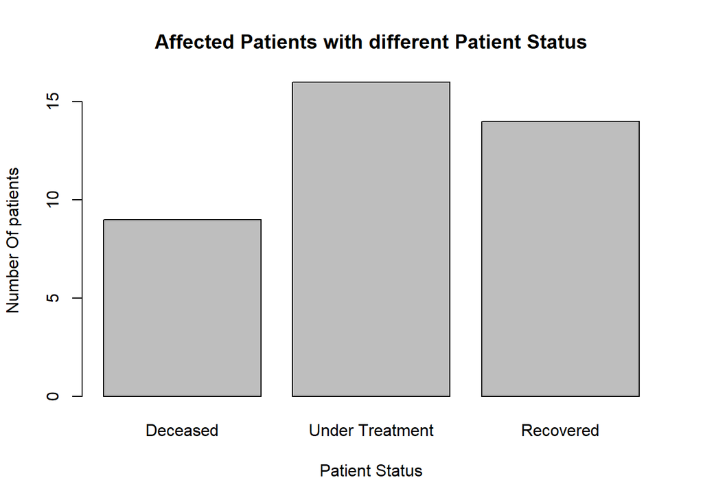

```r
barplot(Query8$TotalNumber,names.arg = Query8$patientStatus, xlab = "Patient Status", ylab = "Number Of patients", main = "Affected Patients with different Patient Status")
```

**Close the database Connection**

```r
dbDisconnect(conn)
```

```
## [1] TRUE
```